# Marketing Analytics

Chapter 6 · Mechanisms & Heterogeneity

Nils Wlömert

Vienna University of Economics and Business (WU)

October 2026

## Before we start

**Paper quiz on Chapter 5, Part II** *(§5.7–5.10, 8 min)*

- Individual, closed book
- Counts toward participation

**Assignment 3** is running

- Deadline: Group A Sun, Nov 22 · Group B Wed, Nov 25
- Debrief at the start of next session

## Today’s session

6.1 The average effect hides the interesting part  
6.2 Interactions and **marginal effects**  
6.3 Continuous × categorical  
6.4 Continuous × continuous *(short)*  
6.5 Categorical × categorical: a **2 × 3 experiment**  
6.6 Pitfalls: subgroup fishing & power  
6.7 **Mediation**: why does it work?  
6.8 Good and bad controls *(short)*  
6.9 Your group project

**Driving question:** *Why — and for whom — does it work?*

One new ingredient: the **product of two variables**.

# 6.1 The average effect hides the interesting part

## Smart Mix, second wave

- **1,200 users**, randomized to Smart Mix or control
- This time with **covariates**: plan (free/Premium), prior listening, tenure, device
- And one more variable: **new artists discovered** during the four weeks
- Average effect: **+3.7 hours** (95% CI 3.1–4.3)

The product team asks two more questions:

1. **For whom** does it work — free or Premium users? light or heavy listeners?
2. **Why** does it work — does it make users discover new music?

**Moderation** (for whom): the effect *depends on* a third variable. **Mediation** (why): the effect *runs through* a third variable. Easy to confuse — a moderator changes *how large*, a mediator is *part of the path*.

# 6.2 Interactions and marginal effects

## What an interaction term does

$$y = \beta_0 + \beta_1 x + \beta_2 z + \beta_3 (x \times z) + \varepsilon
\qquad \Rightarrow \qquad
\frac{\partial y}{\partial x} = \beta_1 + \beta_3 z$$

- The **marginal effect** of $x$ depends on $z$
- $\beta_1$ = effect of $x$ **when $z = 0$** (a *conditional* effect, not a “main effect”)
- $\beta_3$ = how much the effect of $x$ changes per unit of $z$
- Symmetric: effect of $z$ = $\beta_2 + \beta_3 x$

**Two rules:** (1) if zero is not a meaningful value of $z$, $\beta_1$ is not meaningful either → center (§6.4). (2) **Always keep both main terms**: in R, `x * z` = `x + z + x:z`.

## Parallel, diverging, crossing

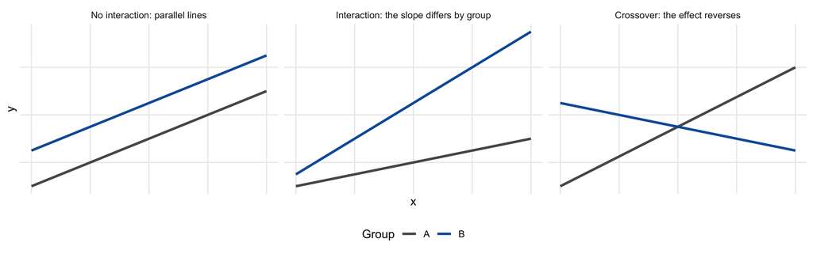

With a group indicator as $z$: **no interaction** = parallel lines (same slope, different level) · **interaction** = different slopes · **crossover** = the effect of $x$ reverses. $\beta_3$ is simply the **difference between the slopes**.

# 6.3 Continuous × categorical

## Face 1: a treatment effect that differs between groups

```r
model_plan <- lm(hours ~ smart_mix * premium + prior_hours + tenure, data = wave2)
coef_table(model_plan)
```

```
                  Estimate Std. Error t value p-value
(Intercept)          1.560      0.469    3.33 < 0.001
smart_mix            4.999      0.378   13.21 < 0.001
premium              2.685      0.431    6.22 < 0.001
prior_hours          0.752      0.017   43.97 < 0.001
tenure               0.028      0.009    3.26   0.001
smart_mix:premium   -3.111      0.590   -5.27 < 0.001
```

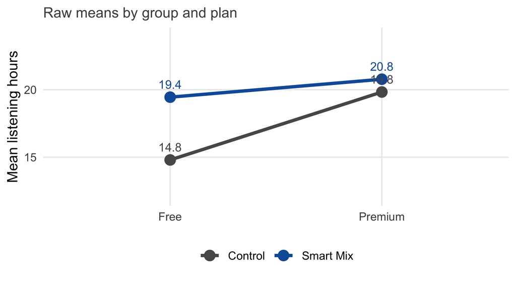

`smart_mix` = effect **for free users** (premium = 0): **5.0 h** · `smart_mix:premium` = how much the effect **differs** for Premium: **−3.1 h** (the heterogeneity test) · effect for Premium = 5.0 − 3.1 = **1.9 h** · `premium` = plan difference **in the control group**.

## Both effects with their uncertainty

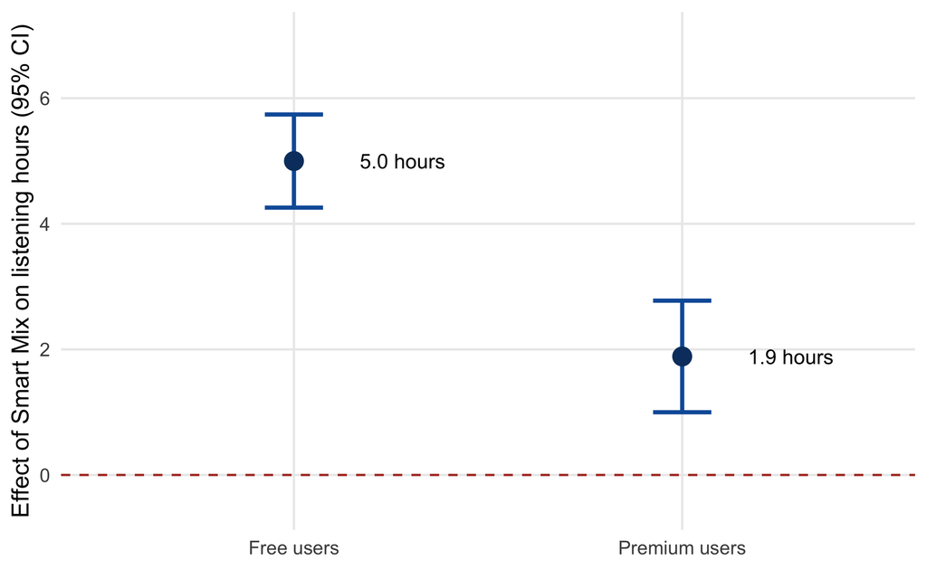

- The CI of the Premium effect is **not** in the output — it combines two coefficients and their covariance (`emmeans` does it for you)
- Actionable: promote Smart Mix to **free users first**

The interaction coefficient tests whether the effects **differ**; the two marginal effects tell you **what they are**. Report both.

## Face 2: a slope that differs between groups

```r
model_genre <- lm(log(streams) ~ log(spend) * genre + log(followers) + placements,
                  data = promo)
coef_table(model_genre)
```

```
                              Estimate Std. Error t value p-value
(Intercept)                     -3.648      0.321  -11.36 < 0.001
log(spend)                       0.206      0.033    6.17 < 0.001
genreHipHop/Rap                 -2.058      0.430   -4.79 < 0.001
genreRock                        0.356      0.654    0.54   0.587
genreElectro/Dance               0.021      0.616    0.03   0.973
log(followers)                   0.507      0.015   33.46 < 0.001
placements                       0.122      0.011   11.42 < 0.001
log(spend):genreHipHop/Rap       0.268      0.052    5.18 < 0.001
log(spend):genreRock            -0.053      0.079   -0.67   0.504
log(spend):genreElectro/Dance    0.005      0.076    0.07   0.946
```

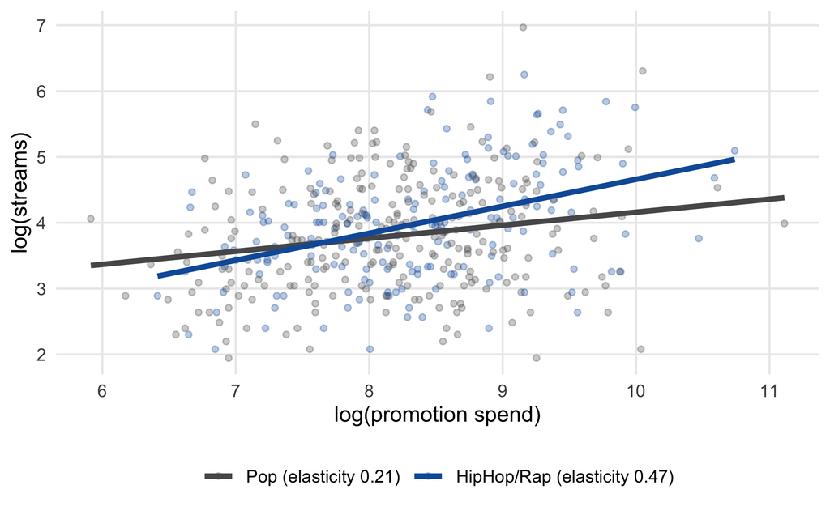

Same model, different question: `log(spend)` = elasticity for **Pop** (reference); `log(spend):genreHipHop/Rap` = **+0.27** → HipHop/Rap elasticity ≈ **0.47**. Rock and Electro: no evidence of a different slope. Genre “main effects” = level differences at **1 euro** of spend.

## Moderation by a continuous variable

```r
model_prior <- lm(hours ~ smart_mix * prior_hours + premium + tenure, data = wave2)
coef_table(model_prior)
```

```
                      Estimate Std. Error t value p-value
(Intercept)              1.446      0.532    2.72   0.007
smart_mix                5.391      0.660    8.16 < 0.001
prior_hours              0.797      0.023   34.43 < 0.001
premium                  1.041      0.301    3.46 < 0.001
tenure                   0.027      0.009    3.15   0.002
smart_mix:prior_hours   -0.096      0.034   -2.82   0.005
```

Marginal effect of Smart Mix = 5.39 − 0.096 × prior hours:

- 10 hours before → **4.4 h** · 30 hours → **2.5 h**
- `smart_mix` alone = effect at **zero** prior hours — a user who hardly exists

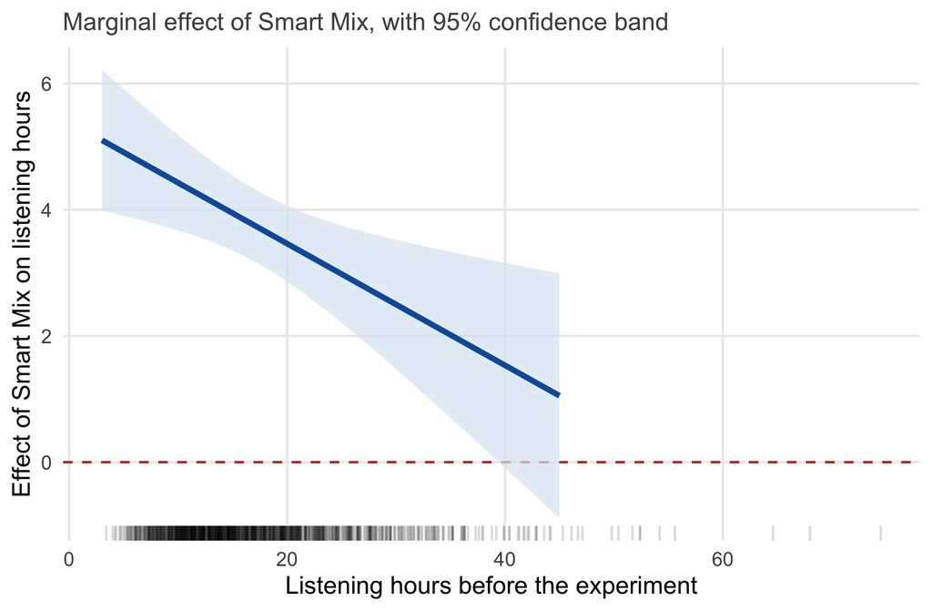

With a continuous moderator, report the effect at **meaningful values** (10th / 50th / 90th percentile) or as a **curve with its confidence band** — never the coefficient at zero.

## Your turn (5 min)

Fit the interaction of Smart Mix with **device**:

```r
model_device <- lm(hours ~ smart_mix * device + prior_hours + premium + tenure, data = wave2)
coef_table(model_device)
```

For which device is the effect of Smart Mix largest? Compute the effect for each device from the coefficients. Are the differences significant?

# 6.4 Continuous × continuous

## Spend × followers: the problem with “main effects”

**Uncentered:**

```r
m_cc <- lm(log(streams) ~ log(spend) * log(followers) +
             placements + genre, data = promo)
coef_table(m_cc)[2:3, ]
```

```
               Estimate Std. Error t value p-value
log(spend)       -0.896      0.183   -4.90 < 0.001
log(followers)   -0.422      0.143   -2.96   0.003
```

A **negative** spend elasticity? It is the elasticity for an artist with **one follower** (log = 0).

**Centered at the means:**

```r
promo_c <- promo |> mutate(ls = log(spend) - mean(log(spend)),
                           lf = log(followers) - mean(log(followers)))
m_ccc <- lm(log(streams) ~ ls * lf + placements + genre, data = promo_c)
coef_table(m_ccc)[c(2, 3, 8), ]
```

```
      Estimate Std. Error t value p-value
ls       0.299      0.022   13.31 < 0.001
lf       0.508      0.015   33.87 < 0.001
ls:lf    0.113      0.017    6.53 < 0.001
```

Now `ls` = elasticity for an **average** artist; the interaction is unchanged.

Centering changes the main effects (now “at the mean of the other variable”), **not** the interaction or the fit. Communicate with a **plot of the marginal effect** — book §6.4 — not with the table.

# 6.5 Categorical × categorical: a 2 × 3 experiment

## Are AI-made ads judged as creative as human-made ads?

- **360 respondents** rate the creativity of an ad (0–100)
- Factor 1 — **source** of the design: Human · AI · Human + AI
- Factor 2 — **disclosure**: source revealed · not revealed
- 2 × 3 = **6 cells**, 60 respondents each, randomized

[figure not shown]

## The regression: six coefficients, six cell means

```r
model_ads <- lm(creativity ~ source * disclosure, data = ads)
coef_table(model_ads)
```

```
                                        Estimate Std. Error t value p-value
(Intercept)                               61.800      1.854   33.33 < 0.001
sourceAI                                 -13.533      2.622   -5.16 < 0.001
sourceHuman + AI                         -18.250      2.622   -6.96 < 0.001
disclosureNot revealed                    -9.667      2.622   -3.69 < 0.001
sourceAI:disclosureNot revealed           22.233      3.708    6.00 < 0.001
sourceHuman + AI:disclosureNot revealed   28.150      3.708    7.59 < 0.001
```

| Coefficient | Meaning (reference: Human, Revealed) |
| --- | --- |
| `(Intercept)` 61.8 | Human designs, source revealed |
| `sourceAI` −13.5 · `sourceHuman + AI` −18.3 | AI / hybrid designs, *when revealed*, vs. human |
| `disclosureNot revealed` −9.7 | *Human* designs: not revealed vs. revealed |
| `sourceAI:…` +22.2 · `sourceHuman + AI:…` +28.2 | The **extra** gain of AI / hybrid designs when not revealed, beyond the two main effects |

## Step 1: is there an interaction at all?

```r
anova(model_ads)
```

```
Analysis of Variance Table

Response: creativity
                   Df Sum Sq Mean Sq F value  Pr(>F)
source              2   1055     527    2.56   0.079 .
disclosure          1   4572    4572   22.17 3.6e-06 ***
source:disclosure   2  13218    6609   32.04 1.6e-13 ***
Residuals         354  73021     206
---
Signif. codes:  0 '***' 0.001 '**' 0.01 '*' 0.05 '.' 0.1 ' ' 1
```

The ANOVA table tests each factor and the **interaction as a whole** (two coefficients at once). Interaction highly significant → the effect of the source depends on disclosure → **do not interpret the main effects on their own**. (Unbalanced cells: `car::Anova(model_ads, type = 2)`.)

## Step 2: which cells differ? Estimated marginal means

```r
library(emmeans)
emm <- emmeans(model_ads, ~ source | disclosure)
pairs(emm)
```

```
disclosure = Revealed:
 contrast             estimate   SE  df t.ratio p.value
 Human - AI              13.53 2.62 354   5.161  <.0001
 Human - (Human + AI)    18.25 2.62 354   6.960  <.0001
 AI - (Human + AI)        4.72 2.62 354   1.799  0.1715

disclosure = Not revealed:
 contrast             estimate   SE  df t.ratio p.value
 Human - AI              -8.70 2.62 354  -3.318  0.0029
 Human - (Human + AI)    -9.90 2.62 354  -3.775  0.0005
 AI - (Human + AI)       -1.20 2.62 354  -0.458  0.8910

P value adjustment: tukey method for comparing a family of 3 estimates
```

From “there is an interaction” to “**where exactly** are the differences”: revealed → human beats AI (14 points) and hybrid; not revealed → AI and hybrid beat human by 9–10 points. *p*-values **Tukey-adjusted** within each disclosure condition — the two-step logic of Chapter 4, with one extra dimension.

## Your turn (5 min)

1. Rebuild the cell mean for **hybrid** designs with the source **not revealed** from the coefficients of `model_ads`. Check it against the table of cell means.
2. Which **single number** in the regression output answers: “does disclosure change the rating of hybrid designs *more* than it changes the rating of human designs?”

# 6.6 The pitfalls of looking for heterogeneity

## Subgroup fishing

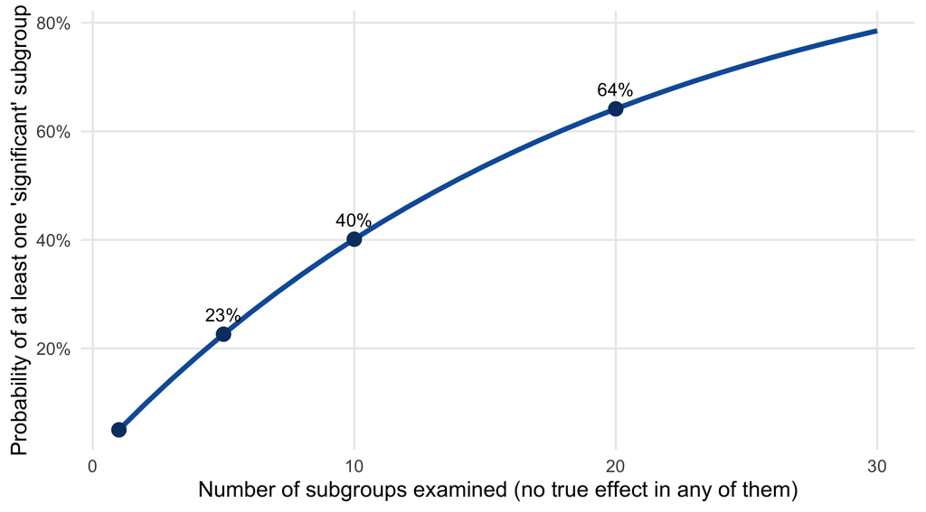

- Plan × device × tenure × age × country … = dozens of subgroups
- Testing each = **multiple testing** (Chapter 4)
- 20 subgroups, no heterogeneity: **64%** chance of a “significant” one
- Live demo: subgroup-fishing widget, book §6.6

“Smart Mix works particularly well for Android users aged 25–34” after twenty subgroups = **noise with a story**.

## Interactions need large samples

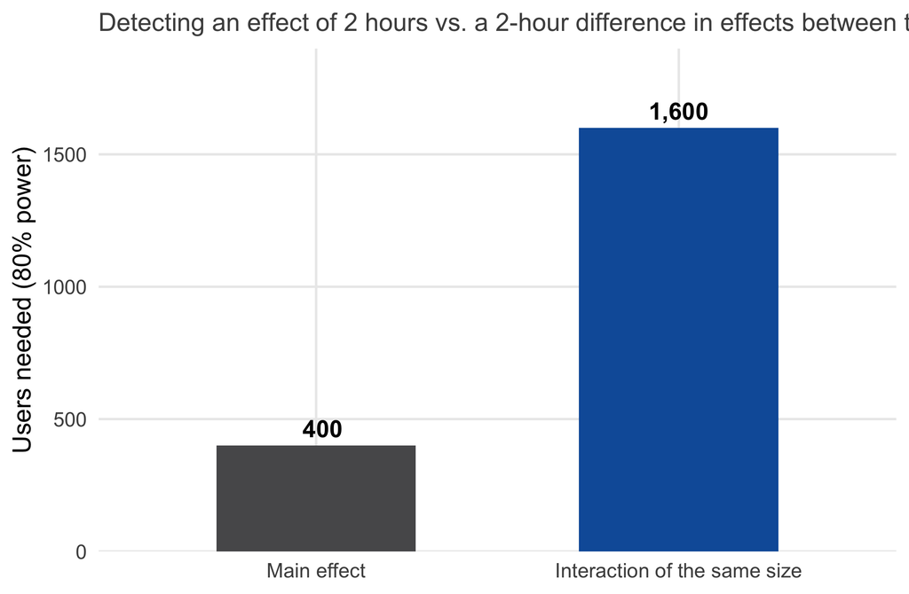

- SE of a *difference between two effects* = **2 ×** SE of the overall effect
- Same power → **4 × the sample** for an interaction as large as a main effect
- And interactions are usually **smaller**
- Underpowered: miss real heterogeneity, **exaggerate** what you find

**Pre-register** the moderators you expect and test those. Everything else is exploratory — a hypothesis for the *next* experiment. Not significant → “no evidence that the effect differs”, not “the effect is the same”.

# 6.7 Mediation: why does it work?

## Total = direct + indirect

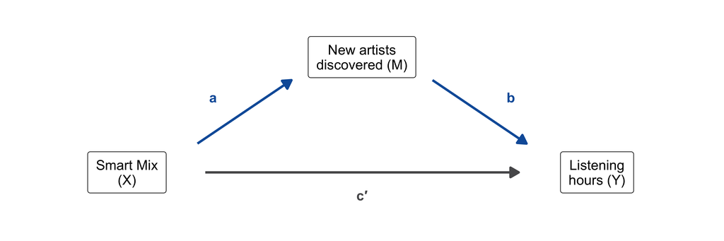

- **Indirect effect**: Smart Mix → new artists → hours = **a × b**
- **Direct effect** c′: everything else (convenience, habit, curiosity)
- **Total** = direct + indirect

Hypothesis of the product team: Smart Mix works **because** it makes users discover new music. If true, improving discovery improves the effect.

## Three regressions

```r
model_m <- lm(new_artists ~ smart_mix + prior_hours + premium, data = wave2)          # path a
model_y <- lm(hours ~ smart_mix + new_artists + prior_hours + premium + tenure, data = wave2)   # paths b and c'
a <- coef(model_m)["smart_mix"]; b <- coef(model_y)["new_artists"]; c_direct <- coef(model_y)["smart_mix"]
c(a = unname(a), b = unname(b), direct = unname(c_direct), indirect = unname(a * b), total = unname(c_direct + a * b))
```

```
       a        b   direct indirect    total
  3.6185   0.3909   2.3063   1.4146   3.7209
```

- **a** = 3.6 more new artists with Smart Mix
- **b** = 0.39 hours per new artist, holding Smart Mix constant
- **c′** = 2.31 hours direct — down from the total 3.72

Indirect effect a × b = **1.42 hours = 38%** of the effect runs through discovery. Discovery is **an** important mechanism — not the only one.

## Uncertainty of the indirect effect: bootstrap

```r
set.seed(1)
boot_indirect <- replicate(2000, {
  d_boot <- wave2[sample(nrow(wave2), replace = TRUE), ]
  coef(lm(new_artists ~ smart_mix + prior_hours + premium, data = d_boot))["smart_mix"] *
    coef(lm(hours ~ smart_mix + new_artists + prior_hours + premium + tenure, data = d_boot))["new_artists"]
})
quantile(boot_indirect, c(0.025, 0.975))
```

```
  2.5%  97.5%
0.9861 1.8632
```

A product of two estimates is **not normally distributed** → no textbook standard error → **bootstrap** (Chapter 3): resample users, re-estimate, look at the distribution. Report **total, direct, indirect** with uncertainty, plus the **share mediated**. (`mediation` package: `mediate()` does this incl. logistic outcomes.)

## The catch: nobody randomized the mediator

Live demo: book §6.7 — mediation widget, switch on the **unobserved confounder of M and Y**

https://wu-rds.github.io/MA2026/06-mechanisms.html#sec-mech-mediation

Randomization identifies the **total** effect. The **split** needs one more assumption: **no unobserved confounder of mediator and outcome** (curious users discover more *and* listen more). Untestable — and the same problem as Chapter 5, one step down the chain.

What helps: measure likely confounders of M; **manipulate the mediator** (Smart Mix with vs. without discovery).

# 6.8 Good and bad controls

## Fork, pipe, collider

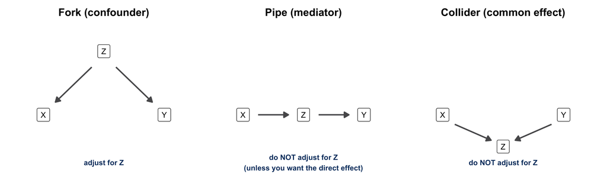

**Fork** = confounder → adjust (Ch. 5). **Pipe** = mediator → adjusting gives the *direct* effect, not the total. **Collider** = common effect → adjusting (or selecting on it) **creates** a spurious association. Draw the diagram **before** the analysis.

# 6.9 Your group project

## Moderation and mediation with 120 respondents

**Add a moderator?**

- Only if central to your topic and you can state the **expected direction** in advance
- Measure it **before** the manipulation
- `outcome ~ condition * moderator`
- 60 per condition → only **large** interactions detectable
- A 2 × 2 spreads you over cells of 30

**Measure a mediator?**

- One or two plausible mechanisms, measured **after** the manipulation (perceived quality, trust, attention)
- Cheap — and tells you **where the chain broke** if the manipulation did not work
- Report total / direct / indirect **with the caveats**

State what was **planned** and what was **exploratory**. “No evidence that the effect differs” ≠ “the effect is the same”.

## Learning check

1. `smart_mix` = 5.0, `smart_mix:premium` = −3.1. Effect for free users? For Premium? What does the interaction’s *p*-value test?
2. 2 × 2: intercept 40, `framingYearly` −5, `trialYes` +8, `framingYearly:trialYes` +6. The four cell means? Where does the trial help more?
3. A loyalty program’s total effect on spending, with “store visits” as a control — fork, pipe, or collider? Consequence?
4. 25 segments tested, “works particularly well for returning customers on tablets” (*p* = .02). Problem — and what next?

## Next session

**Module 8 · Survey design** — *from research question to questionnaire*

- Measuring constructs: items, scales, reliability
- Embedding your experiment in a Qualtrics survey
- Questionnaire structure, pretesting, data collection

Bring your group’s **research question and planned manipulation** — we will work on your questionnaires in class.